# COD_202411020_MGK_IBS7048_week12_statistical_microbiome_analysis

Minsik Kim

2023-11-08

This analysis pipe noted https://github.com/minsiksudo/BTE3207_Advanced_Biostatistics.

# Roading the data

from previous lecture.. we generated a phyloseq object. it can be saved to hard disk using the below command.

`saveRDS(ps, "phyloseq_example.rds")`

And it can be loaded to a new R session like below!

```r
getwd()
```

```
## [1] "/Users/minsikkim/Dropbox (Personal)"
```

```r
library(phyloseq)
library(tidyverse)
library(microbiome)
library(vegan)
```

```r
library(ggplot2)
#source("https://raw.githubusercontent.com/joey711/phyloseq/master/inst/scripts/installer.R",
#       local = TRUE)


phyloseq <- readRDS("Inha/5_Lectures/2024/Advanced biostatistics/scripts/BTE3207_Advanced_Biostatistics/phyloseq_example.rds")
phyloseq %>% sample_data
```

```
##        Subject Gender Day  When
## F3D0         3      F   0 Early
## F3D1         3      F   1 Early
## F3D141       3      F 141  Late
## F3D142       3      F 142  Late
## F3D143       3      F 143  Late
## F3D144       3      F 144  Late
## F3D145       3      F 145  Late
## F3D146       3      F 146  Late
## F3D147       3      F 147  Late
## F3D148       3      F 148  Late
## F3D149       3      F 149  Late
## F3D150       3      F 150  Late
## F3D2         3      F   2 Early
## F3D3         3      F   3 Early
## F3D5         3      F   5 Early
## F3D6         3      F   6 Early
## F3D7         3      F   7 Early
## F3D8         3      F   8 Early
## F3D9         3      F   9 Early
```

# Basics of statistical tests

## MPG dataset

MPG dataset is basic data installed in ggplot

```r
head(mpg)
```

```
## # A tibble: 6 × 11
##   manufacturer model displ  year   cyl trans      drv     cty   hwy fl    class
##   <chr>        <chr> <dbl> <int> <int> <chr>      <chr> <int> <int> <chr> <chr>
## 1 audi         a4      1.8  1999     4 auto(l5)   f        18    29 p     compa…
## 2 audi         a4      1.8  1999     4 manual(m5) f        21    29 p     compa…
## 3 audi         a4      2    2008     4 manual(m6) f        20    31 p     compa…
## 4 audi         a4      2    2008     4 auto(av)   f        21    30 p     compa…
## 5 audi         a4      2.8  1999     6 auto(l5)   f        16    26 p     compa…
## 6 audi         a4      2.8  1999     6 manual(m5) f        18    26 p     compa…
```

Double-check the data type.

```r
str(mpg)
```

```
## tibble [234 × 11] (S3: tbl_df/tbl/data.frame)
##  $ manufacturer: chr [1:234] "audi" "audi" "audi" "audi" ...
##  $ model       : chr [1:234] "a4" "a4" "a4" "a4" ...
##  $ displ       : num [1:234] 1.8 1.8 2 2 2.8 2.8 3.1 1.8 1.8 2 ...
##  $ year        : int [1:234] 1999 1999 2008 2008 1999 1999 2008 1999 1999 2008 ...
##  $ cyl         : int [1:234] 4 4 4 4 6 6 6 4 4 4 ...
##  $ trans       : chr [1:234] "auto(l5)" "manual(m5)" "manual(m6)" "auto(av)" ...
##  $ drv         : chr [1:234] "f" "f" "f" "f" ...
##  $ cty         : int [1:234] 18 21 20 21 16 18 18 18 16 20 ...
##  $ hwy         : int [1:234] 29 29 31 30 26 26 27 26 25 28 ...
##  $ fl          : chr [1:234] "p" "p" "p" "p" ...
##  $ class       : chr [1:234] "compact" "compact" "compact" "compact" ...
```

t.test fucntion will conduct basic t-test

Paired t-test

```r
t.test(mpg$cty, mpg$hwy, paired = T)
```

```
##
##  Paired t-test
##
## data:  mpg$cty and mpg$hwy
## t = -44.492, df = 233, p-value < 2.2e-16
## alternative hypothesis: true mean difference is not equal to 0
## 95 percent confidence interval:
##  -6.872628 -6.289765
## sample estimates:
## mean difference
##       -6.581197
```

Unpaired t-test

```r
mpg$class
```

```
##   [1] "compact"    "compact"    "compact"    "compact"    "compact"
##   [6] "compact"    "compact"    "compact"    "compact"    "compact"
##  [11] "compact"    "compact"    "compact"    "compact"    "compact"
##  [16] "midsize"    "midsize"    "midsize"    "suv"        "suv"
##  [21] "suv"        "suv"        "suv"        "2seater"    "2seater"
##  [26] "2seater"    "2seater"    "2seater"    "suv"        "suv"
##  [31] "suv"        "suv"        "midsize"    "midsize"    "midsize"
##  [36] "midsize"    "midsize"    "minivan"    "minivan"    "minivan"
##  [41] "minivan"    "minivan"    "minivan"    "minivan"    "minivan"
##  [46] "minivan"    "minivan"    "minivan"    "pickup"     "pickup"
##  [51] "pickup"     "pickup"     "pickup"     "pickup"     "pickup"
##  [56] "pickup"     "pickup"     "suv"        "suv"        "suv"
##  [61] "suv"        "suv"        "suv"        "suv"        "pickup"
##  [66] "pickup"     "pickup"     "pickup"     "pickup"     "pickup"
##  [71] "pickup"     "pickup"     "pickup"     "pickup"     "suv"
```

[output cut: 32 more lines]

```r
mpg %>% filter(class == "2seater")%>% .$cty
```

```
## [1] 16 15 16 15 15
```

```r
city_mpg_2seater <- mpg %>% filter(class == "2seater") %>% .$cty

city_mpg_midsize <- mpg %>% filter(class == "midsize") %>% .$cty

city_mpg_2seater
```

```
## [1] 16 15 16 15 15
```

```r
city_mpg_midsize
```

```
##  [1] 15 17 16 19 22 18 18 17 18 18 21 21 18 18 19 23 23 19 19 18 19 19 18 16 17
## [26] 18 16 21 21 21 21 18 18 19 21 18 19 21 16 18 17
```

```r
t.test(city_mpg_2seater,
       city_mpg_midsize,
       paired = F,
       var.equal = F)
```

```
##
##  Welch Two Sample t-test
##
## data:  city_mpg_2seater and city_mpg_midsize
## t = -8.5965, df = 20.862, p-value = 2.69e-08
## alternative hypothesis: true difference in means is not equal to 0
## 95 percent confidence interval:
##  -4.168314 -2.543882
## sample estimates:
## mean of x mean of y
##   15.4000   18.7561
```

# Linear model

## Univariate linear model

Boxplot of categorical x, continuous y

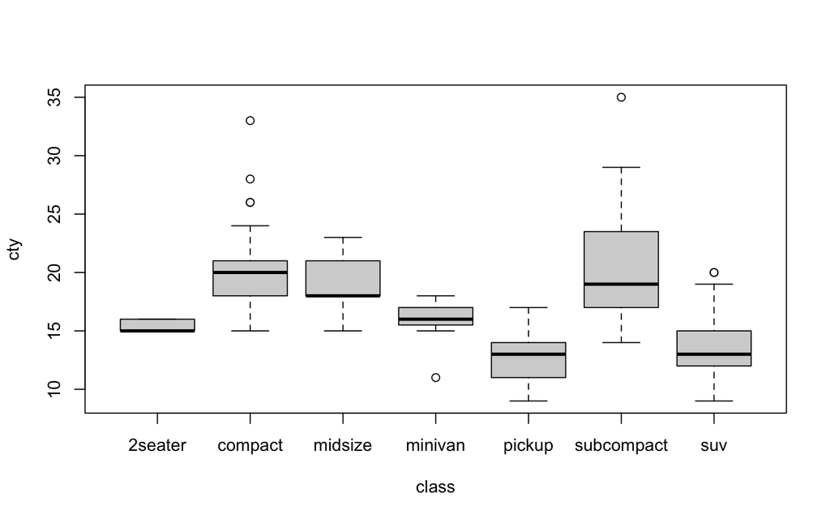

```r
boxplot(data = mpg, cty ~ class)
```

Linear model

```r
lm(data = mpg,
       cty ~ class)
```

```
##
## Call:
## lm(formula = cty ~ class, data = mpg)
##
## Coefficients:
##     (Intercept)     classcompact     classmidsize     classminivan
##         15.4000           4.7277           3.3561           0.4182
##     classpickup  classsubcompact         classsuv
##         -2.4000           4.9714          -1.9000
```

Linear model - the output can be stored

```r
lm_result_mpg <-
        lm(data = mpg,
           cty ~ class)

lm_result_mpg
```

```
##
## Call:
## lm(formula = cty ~ class, data = mpg)
##
## Coefficients:
##     (Intercept)     classcompact     classmidsize     classminivan
##         15.4000           4.7277           3.3561           0.4182
##     classpickup  classsubcompact         classsuv
##         -2.4000           4.9714          -1.9000
```

The result of lm is a list having multiple caclulated factors

```r
lm_result_mpg %>% names
```

```
##  [1] "coefficients"  "residuals"     "effects"       "rank"
##  [5] "fitted.values" "assign"        "qr"            "df.residual"
##  [9] "contrasts"     "xlevels"       "call"          "terms"
## [13] "model"
```

Summary of a linear model

```r
summary(lm_result_mpg)
```

```
##
## Call:
## lm(formula = cty ~ class, data = mpg)
##
## Residuals:
##     Min      1Q  Median      3Q     Max
## -6.3714 -1.7561 -0.1277  1.0000 14.6286
##
## Coefficients:
##                 Estimate Std. Error t value Pr(>|t|)
## (Intercept)      15.4000     1.3024  11.824  < 2e-16 ***
## classcompact      4.7277     1.3699   3.451 0.000666 ***
## classmidsize      3.3561     1.3796   2.433 0.015759 *
## classminivan      0.4182     1.5708   0.266 0.790307
## classpickup      -2.4000     1.3976  -1.717 0.087304 .
## classsubcompact   4.9714     1.3923   3.571 0.000435 ***
## classsuv         -1.9000     1.3539  -1.403 0.161884
## ---
## Signif. codes:  0 '***' 0.001 '**' 0.01 '*' 0.05 '.' 0.1 ' ' 1
##
## Residual standard error: 2.912 on 227 degrees of freedom
## Multiple R-squared:  0.5438, Adjusted R-squared:  0.5317
## F-statistic:  45.1 on 6 and 227 DF,  p-value: < 2.2e-16
```

This result will show you how different data is. (by the factor label of `class`)

You have 1. Estimate (beta) 2. Standard errors 3. **p**-values 4. R-squared values

## ANOVA

Analysis of variance for linear model can be done to this linear model result.

```r
anova(lm_result_mpg)
```

```
## Analysis of Variance Table
##
## Response: cty
##            Df Sum Sq Mean Sq F value    Pr(>F)
## class       6 2295.0  382.51  45.099 < 2.2e-16 ***
## Residuals 227 1925.3    8.48
## ---
## Signif. codes:  0 '***' 0.001 '**' 0.01 '*' 0.05 '.' 0.1 ' ' 1
```

## How can we test different multiple associations?

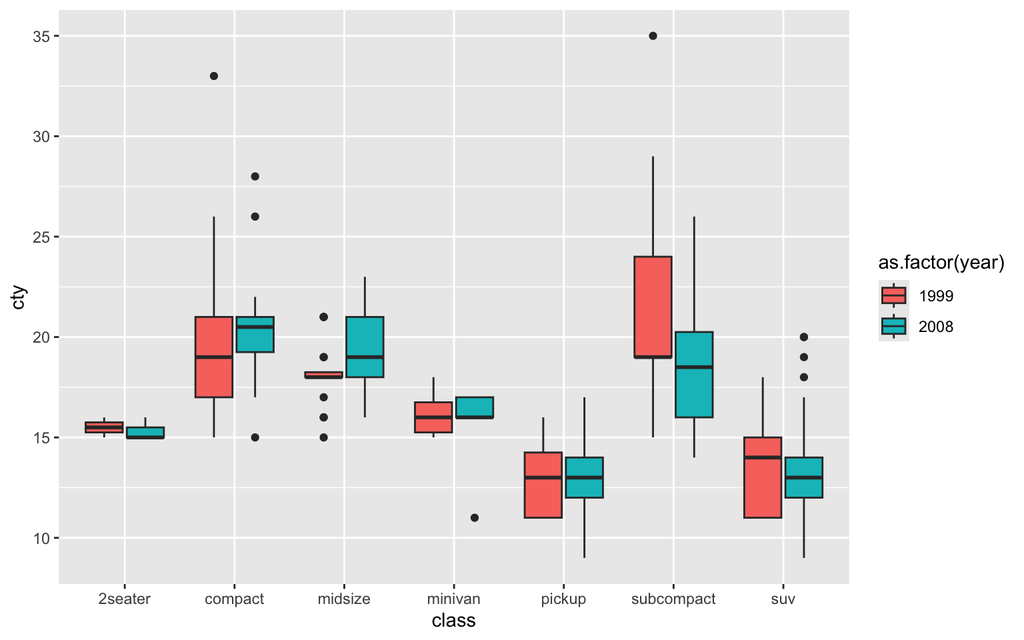

```r
ggplot(mpg,
       aes(y = cty, x = class, fill = as.factor(year))) +
        geom_boxplot()
```

## Anova - Multivariate

```r
lm(data = mpg,
        formula = hwy ~ class + as.factor(year)) %>%
        anova
```

```
## Analysis of Variance Table
##
## Response: hwy
##                  Df Sum Sq Mean Sq F value Pr(>F)
## class             6 5683.2  947.21 83.4157 <2e-16 ***
## as.factor(year)   1   12.1   12.15  1.0699 0.3021
## Residuals       226 2566.3   11.36
## ---
## Signif. codes:  0 '***' 0.001 '**' 0.01 '*' 0.05 '.' 0.1 ' ' 1
```

## linear model - Multivariate

Multiple linear regression can be don by just *adding a new variable to formula*

```r
lm(data = mpg,
        formula = hwy ~ class * as.factor(year)) %>%
        summary
```

```
##
## Call:
## lm(formula = hwy ~ class * as.factor(year), data = mpg)
##
## Residuals:
##    Min     1Q Median     3Q    Max
## -8.000 -1.812 -0.500  1.341 16.080
##
## Coefficients:
##                                     Estimate Std. Error t value Pr(>|t|)
## (Intercept)                          24.5000     2.3822  10.285  < 2e-16 ***
## classcompact                          3.4200     2.4756   1.381  0.16854
## classmidsize                          2.0000     2.4984   0.800  0.42429
## classminivan                         -2.0000     2.7507  -0.727  0.46795
## classpickup                          -7.6875     2.5267  -3.043  0.00263 **
## classsubcompact                       4.5000     2.5044   1.797  0.07373 .
## classsuv                             -6.9483     2.4629  -2.821  0.00522 **
## as.factor(year)2008                   0.5000     3.0754   0.163  0.87100
## classcompact:as.factor(year)2008      0.3073     3.2292   0.095  0.92428
## classmidsize:as.factor(year)2008      1.0476     3.2505   0.322  0.74754
## classminivan:as.factor(year)2008     -0.8000     3.6904  -0.217  0.82858
## classpickup:as.factor(year)2008      -0.3713     3.2916  -0.113  0.91029
## classsubcompact:as.factor(year)2008  -2.3750     3.2809  -0.724  0.46991
## classsuv:as.factor(year)2008          0.5846     3.1927   0.183  0.85487
## ---
## Signif. codes:  0 '***' 0.001 '**' 0.01 '*' 0.05 '.' 0.1 ' ' 1
##
## Residual standard error: 3.369 on 220 degrees of freedom
## Multiple R-squared:  0.6978, Adjusted R-squared:  0.6799
## F-statistic: 39.07 on 13 and 220 DF,  p-value: < 2.2e-16
```

# Statistical tests for alpha diversity

```r
microbiome::alpha(phyloseq)
```

```
## Observed richness
```

```
## Other forms of richness
```

```
## Diversity
```

```
## Evenness
```

```
## Dominance
```

```
## Rarity
```

```
##        observed chao1 diversity_inverse_simpson diversity_gini_simpson
## F3D0        101   101                  28.30269              0.9646677
## F3D1         95    95                  33.63697              0.9702708
## F3D141       72    72                  20.40816              0.9510000
## F3D142       46    46                  16.18065              0.9381978
## F3D143       52    52                  18.96604              0.9472742
## F3D144       48    48                  15.64626              0.9360870
## F3D145       65    65                  15.90272              0.9371177
## F3D146       80    80                  23.17233              0.9568451
## F3D147      100   100                  17.67047              0.9434084
## F3D148       92    92                  20.35859              0.9508807
## F3D149      107   107                  23.33034              0.9571374
## F3D150       72    72                  22.03383              0.9546153
## F3D2        128   128                  14.24080              0.9297792
## F3D3         62    62                  12.77515              0.9217230
## F3D5         79    79                  26.61261              0.9624238
## F3D6         85    85                  16.09561              0.9378712
## F3D7         56    56                  12.45250              0.9196948
## F3D8         91    91                  21.97649              0.9544968
## F3D9        103   103                  23.49765              0.9574426
##        diversity_shannon diversity_fisher diversity_coverage evenness_camargo
## F3D0            3.858471        16.981200                 10        0.3427514
## F3D1            3.961659        16.721685                 13        0.4009949
## F3D141          3.443176        11.995626                  7        0.3073986
## F3D142          3.105778         8.022685                  6        0.3398586
## F3D143          3.291013         9.279171                  7        0.3553785
## F3D144          3.066893         7.815491                  6        0.3135287
## F3D145          3.108397        10.265899                  6        0.2482799
## F3D146          3.614385        14.274466                  8        0.3298440
## F3D147          3.339392        14.687532                  6        0.2132134
## F3D148          3.435338        14.040249                  7        0.2454306
## F3D149          3.633402        16.580009                  8        0.2597679
## F3D150          3.551333        12.314447                  8        0.3416144
## F3D2            3.550710        18.859482                  6        0.2410682
## F3D3            3.024484         9.826275                  5        0.2430211
## F3D5            3.730210        14.243093                  9        0.3807388
## F3D6            3.395656        13.767017                  6        0.2752713
## F3D7            2.965860         9.152918                  5        0.2539099
## F3D8            3.685304        16.216649                  8        0.3264930
## F3D9            3.755616        17.681589                  8        0.3140676
```

[output cut: 65 more lines]

```
## F3D143                   2.037479          0.005577689           0.006374502
## F3D144                   2.018215          0.010206897           0.005517241
## F3D145                   2.030860          0.028645833           0.012673611
## F3D146                   2.046630          0.012943308           0.040383122
## F3D147                   2.046947          0.055024464           0.022581859
## F3D148                   2.045807          0.054125547           0.022586224
## F3D149                   2.045309          0.048615736           0.041004662
## F3D150                   2.040085          0.012000000           0.029882353
## F3D2                     1.994599          0.049173455           0.053066603
## F3D3                     2.046069          0.022621917           0.017059151
## F3D5                     2.050813          0.013747594           0.032444322
## F3D6                     2.053307          0.028800970           0.031832651
## F3D7                     2.048982          0.019049916           0.008680974
## F3D8                     2.055754          0.018325792           0.063122172
## F3D9                     2.050676          0.034829203           0.074514401
```

```r
sample_data_with_alpha <-
        phyloseq %>%
        sample_data() %>%
        merge(., #Merge function will do the same thing as vloopup at excel
              microbiome::alpha(phyloseq),
              by = 0) %>%
        column_to_rownames("Row.names") %>%
        sample_data
```

```
## Observed richness
```

```
## Other forms of richness
```

```
## Diversity
```

```
## Evenness
```

```
## Dominance
```

```
## Rarity
```

```r
sample_data(phyloseq) <- sample_data_with_alpha
sample_data_with_alpha
```

```
##        Subject Gender Day  When observed chao1 diversity_inverse_simpson
## F3D0         3      F   0 Early      101   101                  28.30269
## F3D1         3      F   1 Early       95    95                  33.63697
## F3D141       3      F 141  Late       72    72                  20.40816
## F3D142       3      F 142  Late       46    46                  16.18065
## F3D143       3      F 143  Late       52    52                  18.96604
## F3D144       3      F 144  Late       48    48                  15.64626
## F3D145       3      F 145  Late       65    65                  15.90272
## F3D146       3      F 146  Late       80    80                  23.17233
## F3D147       3      F 147  Late      100   100                  17.67047
## F3D148       3      F 148  Late       92    92                  20.35859
## F3D149       3      F 149  Late      107   107                  23.33034
## F3D150       3      F 150  Late       72    72                  22.03383
## F3D2         3      F   2 Early      128   128                  14.24080
## F3D3         3      F   3 Early       62    62                  12.77515
## F3D5         3      F   5 Early       79    79                  26.61261
## F3D6         3      F   6 Early       85    85                  16.09561
## F3D7         3      F   7 Early       56    56                  12.45250
## F3D8         3      F   8 Early       91    91                  21.97649
## F3D9         3      F   9 Early      103   103                  23.49765
##        diversity_gini_simpson diversity_shannon diversity_fisher
## F3D0                0.9646677          3.858471        16.981200
## F3D1                0.9702708          3.961659        16.721685
## F3D141              0.9510000          3.443176        11.995626
## F3D142              0.9381978          3.105778         8.022685
## F3D143              0.9472742          3.291013         9.279171
## F3D144              0.9360870          3.066893         7.815491
## F3D145              0.9371177          3.108397        10.265899
## F3D146              0.9568451          3.614385        14.274466
## F3D147              0.9434084          3.339392        14.687532
## F3D148              0.9508807          3.435338        14.040249
## F3D149              0.9571374          3.633402        16.580009
## F3D150              0.9546153          3.551333        12.314447
## F3D2                0.9297792          3.550710        18.859482
## F3D3                0.9217230          3.024484         9.826275
## F3D5                0.9624238          3.730210        14.243093
## F3D6                0.9378712          3.395656        13.767017
## F3D7                0.9196948          2.965860         9.152918
## F3D8                0.9544968          3.685304        16.216649
## F3D9                0.9574426          3.755616        17.681589
```

[output cut: 85 more lines]

```
## F3D143          0.005577689           0.006374502
## F3D144          0.010206897           0.005517241
## F3D145          0.028645833           0.012673611
## F3D146          0.012943308           0.040383122
## F3D147          0.055024464           0.022581859
## F3D148          0.054125547           0.022586224
## F3D149          0.048615736           0.041004662
## F3D150          0.012000000           0.029882353
## F3D2            0.049173455           0.053066603
## F3D3            0.022621917           0.017059151
## F3D5            0.013747594           0.032444322
## F3D6            0.028800970           0.031832651
## F3D7            0.019049916           0.008680974
## F3D8            0.018325792           0.063122172
## F3D9            0.034829203           0.074514401
```

# Alpha diversity boxplots

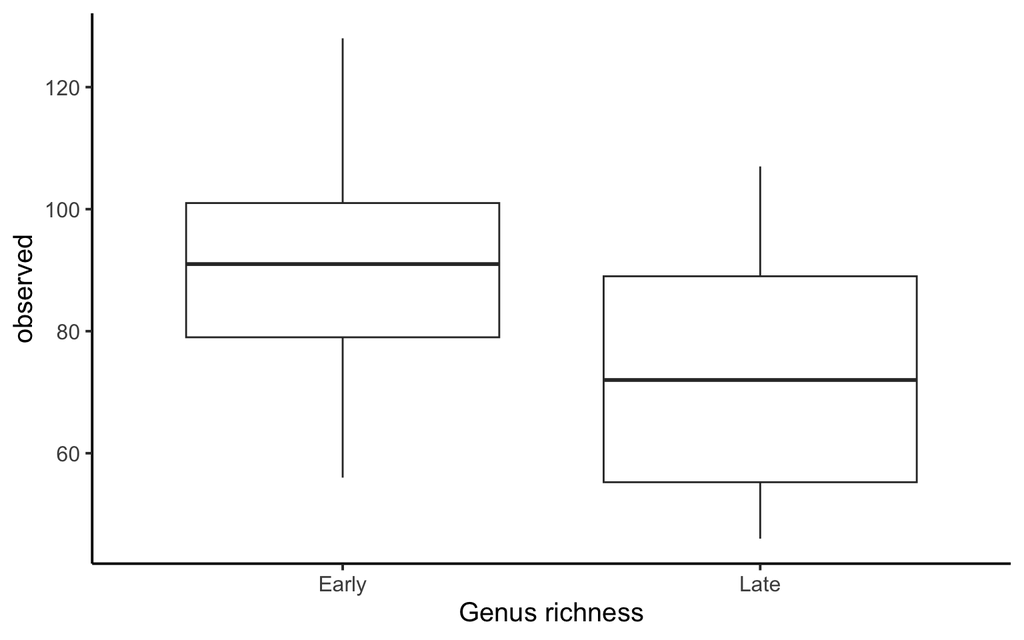

```r
sample_data_with_alpha %>%
        ggplot(aes(x = When, y = observed)) +
        geom_boxplot() +
        xlab("Genus richness") +
        theme_classic(base_size = 15)
```

Statistical tests on alpha diversity (linear model)

```r
sample_data_with_alpha %>%
        data.frame() %>%
        lm(data = ., observed ~ When) %>%
        summary
```

```
##
## Call:
## lm(formula = observed ~ When, data = .)
##
## Residuals:
##    Min     1Q Median     3Q    Max
## -32.89 -15.64  -1.40  13.11  39.11
##
## Coefficients:
##             Estimate Std. Error t value Pr(>|t|)
## (Intercept)   88.889      7.226  12.301 6.88e-10 ***
## WhenLate     -15.489      9.961  -1.555    0.138
## ---
## Signif. codes:  0 '***' 0.001 '**' 0.01 '*' 0.05 '.' 0.1 ' ' 1
##
## Residual standard error: 21.68 on 17 degrees of freedom
## Multiple R-squared:  0.1245, Adjusted R-squared:  0.07303
## F-statistic: 2.418 on 1 and 17 DF,  p-value: 0.1384
```

The difference between those two group - is not statistically significant

How about other outcomes?

```r
sample_data_with_alpha %>%
        data.frame() %>%
        lm(data = ., observed ~ evenness_simpson) %>%
        summary
```

```
##
## Call:
## lm(formula = observed ~ evenness_simpson, data = .)
##
## Residuals:
##     Min      1Q  Median      3Q     Max
## -32.133 -13.320   3.044  14.488  32.319
##
## Coefficients:
##                  Estimate Std. Error t value Pr(>|t|)
## (Intercept)        131.10      17.17   7.637 6.83e-07 ***
## evenness_simpson  -193.25      63.79  -3.030  0.00756 **
## ---
## Signif. codes:  0 '***' 0.001 '**' 0.01 '*' 0.05 '.' 0.1 ' ' 1
##
## Residual standard error: 18.67 on 17 degrees of freedom
## Multiple R-squared:  0.3506, Adjusted R-squared:  0.3124
## F-statistic: 9.178 on 1 and 17 DF,  p-value: 0.007562
```

```r
sample_data_with_alpha %>%
        data.frame() %>%
        lm(data = ., observed ~ dominance_core_abundance) %>%
        summary
```

```
##
## Call:
## lm(formula = observed ~ dominance_core_abundance, data = .)
##
## Residuals:
##     Min      1Q  Median      3Q     Max
## -16.214 -12.941  -2.964   2.150  35.648
##
## Coefficients:
##                          Estimate Std. Error t value Pr(>|t|)
## (Intercept)                257.88      45.21   5.704 2.58e-05 ***
## dominance_core_abundance  -205.13      52.16  -3.932  0.00107 **
## ---
## Signif. codes:  0 '***' 0.001 '**' 0.01 '*' 0.05 '.' 0.1 ' ' 1
##
## Residual standard error: 16.77 on 17 degrees of freedom
## Multiple R-squared:  0.4763, Adjusted R-squared:  0.4455
## F-statistic: 15.46 on 1 and 17 DF,  p-value: 0.001073
```

# How can we say this difference is not because of deeper sequencing?

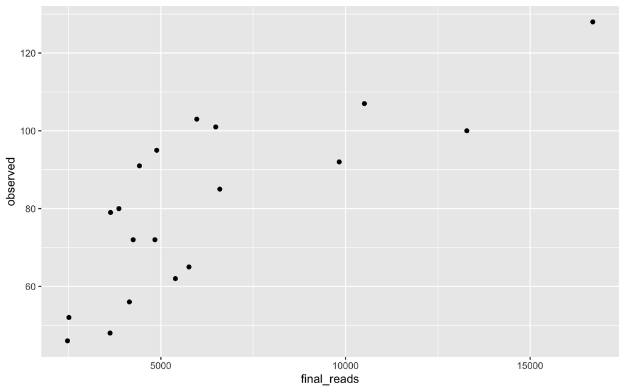

```r
sample_data_with_alpha$final_reads <- phyloseq %>% sample_sums

sample_data_with_alpha %>%
        data.frame() %>%
        ggplot(aes(x = final_reads, y = observed)) +
        geom_point()
```

## Linear model of this association

(As deeper sequencing identified more taxa)

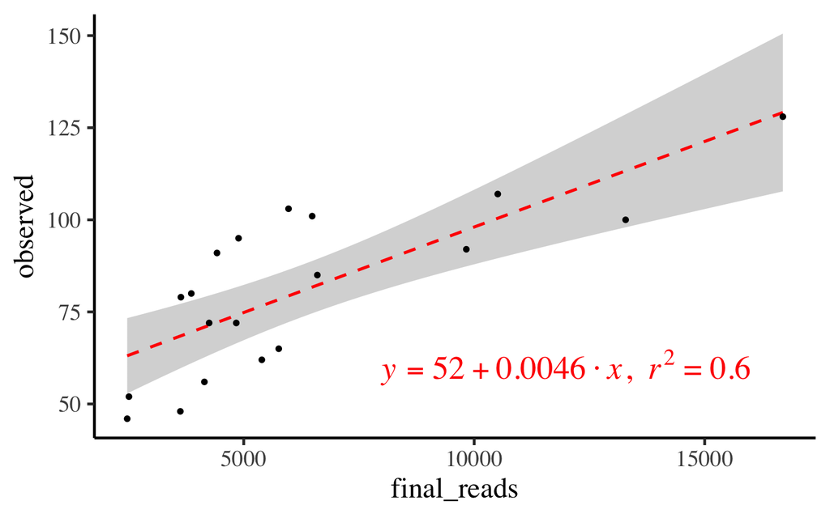

```r
lm_eqn <- function(m){
    eq <- substitute(italic(y) == a + b %.% italic(x)*","~~italic(r)^2~"="~r2,
         list(a = format(unname(coef(m)[1]), digits = 2),
              b = format(unname(coef(m)[2]), digits = 2),
             r2 = format(summary(m)$r.squared, digits = 3)))
    as.character(as.expression(eq));
}


ggplot(data = sample_data_with_alpha, aes(x = final_reads, y = observed)) +
        geom_smooth(method = "lm",
                    se = T,
                    color = "red",
                    linetype = "dashed"
                    ) +  # Plot regression slope
        geom_point() +
        theme_classic( base_family = "serif", base_size = 20) +
        geom_label(x = 12000, y = 60,
                  label = lm_eqn(lm(data = data.frame(sample_data_with_alpha), observed ~ final_reads)),
                  parse = TRUE,
                  family='serif',
                  size = 8, label.size = 0, color = "red")#, fill = alpha(c("white"),1))
```

```r
lm(data = data.frame(sample_data_with_alpha), observed ~ final_reads) %>% summary
```

```
##
## Call:
## lm(formula = observed ~ final_reads, data = data.frame(sample_data_with_alpha))
##
## Residuals:
##     Min      1Q  Median      3Q     Max
## -20.443 -13.328  -1.137  10.476  23.659
##
## Coefficients:
##              Estimate Std. Error t value Pr(>|t|)
## (Intercept) 5.161e+01  6.672e+00   7.736 5.75e-07 ***
## final_reads 4.643e-03  9.189e-04   5.053 9.81e-05 ***
## ---
## Signif. codes:  0 '***' 0.001 '**' 0.01 '*' 0.05 '.' 0.1 ' ' 1
##
## Residual standard error: 14.65 on 17 degrees of freedom
## Multiple R-squared:  0.6003, Adjusted R-squared:  0.5768
## F-statistic: 25.53 on 1 and 17 DF,  p-value: 9.805e-05
```

There is significant correlation !

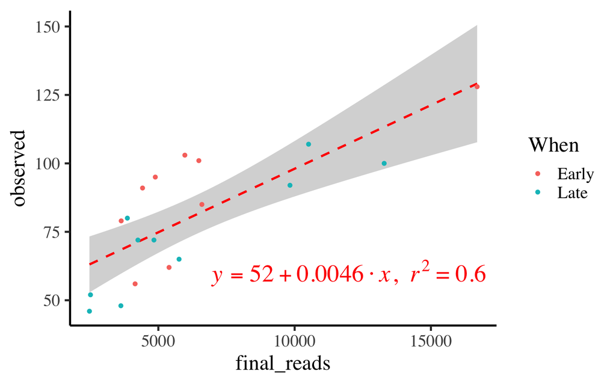

```r
ggplot(data = sample_data_with_alpha, aes(x = final_reads, y = observed)) +
        geom_smooth(method = "lm",
                    se = T,
                    color = "red",
                    linetype = "dashed"
                    ) +  # Plot regression slope
        geom_point(aes(col = When)) +
        theme_classic( base_family = "serif", base_size = 20) +
        geom_label(x = 12000, y = 60,
                  label = lm_eqn(lm(data = data.frame(sample_data_with_alpha), observed ~ final_reads)),
                  parse = TRUE,
                  family='serif',
                  size = 8, label.size = 0, color = "red")#, fill = alpha(c("white"),1))
```

Even for evenness, this association seem to have a significant term in general.

### Multiple linear regression

```r
lm(data = data.frame(sample_data_with_alpha),
   evenness_simpson ~ final_reads + When) %>% summary
```

```
##
## Call:
## lm(formula = evenness_simpson ~ final_reads + When, data = data.frame(sample_data_with_alpha))
##
## Residuals:
##       Min        1Q    Median        3Q       Max
## -0.052392 -0.025102  0.001077  0.019681  0.090052
##
## Coefficients:
##               Estimate Std. Error t value Pr(>|t|)
## (Intercept)  3.348e-01  2.117e-02  15.818 3.44e-11 ***
## final_reads -1.449e-05  2.530e-06  -5.728 3.11e-05 ***
## WhenLate     3.168e-02  1.853e-02   1.710    0.107
## ---
## Signif. codes:  0 '***' 0.001 '**' 0.01 '*' 0.05 '.' 0.1 ' ' 1
##
## Residual standard error: 0.04027 on 16 degrees of freedom
## Multiple R-squared:  0.6972, Adjusted R-squared:  0.6593
## F-statistic: 18.42 on 2 and 16 DF,  p-value: 7.075e-05
```

The association we ‘obsereved’ was not because of experimental condition, but due to different final reads.

```r
glm(data = data.frame(sample_data_with_alpha),
   as.factor(When) ~ final_reads, family = "binomial") %>% summary
```

```
##
## Call:
## glm(formula = as.factor(When) ~ final_reads, family = "binomial",
##     data = data.frame(sample_data_with_alpha))
##
## Coefficients:
##               Estimate Std. Error z value Pr(>|z|)
## (Intercept)  2.820e-01  9.144e-01   0.308    0.758
## final_reads -2.813e-05  1.259e-04  -0.223    0.823
##
## (Dispersion parameter for binomial family taken to be 1)
##
##     Null deviance: 26.287  on 18  degrees of freedom
## Residual deviance: 26.237  on 17  degrees of freedom
## AIC: 30.237
##
## Number of Fisher Scoring iterations: 3
```

So, the *TRUE* change between the samples from early and late phase, was `Dominance`.

How would it change the association for beta diversity?

# Ordination

### Principal Coordinates Analysis with Bray-Curtis dist

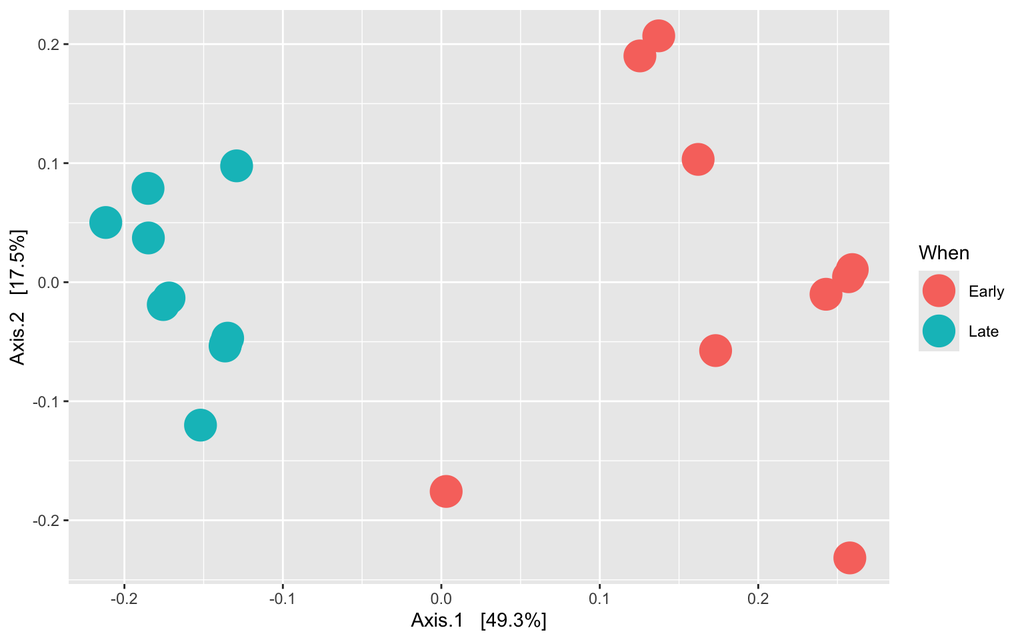

```r
phyloseq_rel <- phyloseq %>% transform_sample_counts(., function(x) {x/sum(x)})

sample_data(phyloseq_rel) <- sample_data_with_alpha

plot_ordination(physeq = phyloseq_rel,
                ordination = ordinate(phyloseq_rel, "PCoA", "bray"),
                col = "When"
                ) +
        geom_point(size = 8)
```

These two groups seems different. Is it really different, by sequencing depth or the sampling phase?

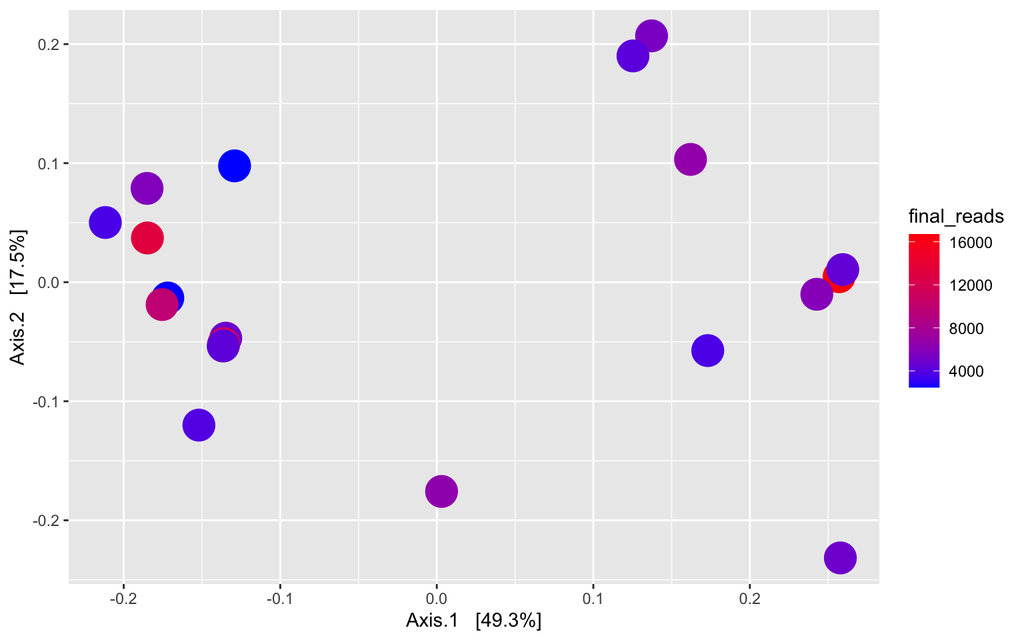

```r
plot_ordination(physeq = phyloseq_rel,
                ordination = ordinate(phyloseq_rel, "PCoA", "bray"),
                col = "final_reads"
                ) +
        geom_point(size = 8) +
        scale_color_gradient(low = "blue", high = "red")
```

Symbols and colors at the sample time

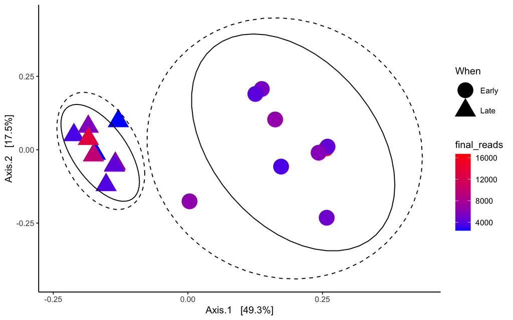

```r
plot_ordination(physeq = phyloseq_rel,
                ordination = ordinate(phyloseq_rel, "PCoA", "bray"),
                shape = "When",
                col = "final_reads"
                ) +
        geom_point(size = 8) +
        scale_color_gradient(low = "blue", high = "red") +
        stat_ellipse(type = "norm", linetype = 2) +
        stat_ellipse(type = "t") +
        theme_classic()
```

```r
        #scale_color_brewer(type = "qual")
```

# PERMANOVA

As betadiversity indices have multiple distances at the same time, the calculation must accompany multiple analyses, at a random order (permutation).

This is permutational anova (PERMANOVA).

## Univariate permutational anova (PERMANOVA).

Based on sampling point

```r
set.seed(1)

adonis(formula = distance(phyloseq, method = "bray") ~ When,
       data = data.frame(sample_data_with_alpha),
       permutations = 10000) %>%
        .$aov.tab
```

```
## Permutation: free
## Number of permutations: 10000
##
## Terms added sequentially (first to last)
##
##           Df SumsOfSqs MeanSqs F.Model      R2 Pr(>F)
## When       1   0.50664 0.50664  5.6658 0.24997  4e-04 ***
## Residuals 17   1.52013 0.08942         0.75003
## Total     18   2.02676                 1.00000
## ---
## Signif. codes:  0 '***' 0.001 '**' 0.01 '*' 0.05 '.' 0.1 ' ' 1
```

There was difference. R-squared shows that the 25% of variance in beta-diversity was explained by `When` variable.

## Multivariate anlaysis

```r
adonis(formula = distance(phyloseq, method = "bray") ~ final_reads + When,
       data = data.frame(sample_data_with_alpha),
       permutations = 10000) %>%
        .$aov.tab
```

```
## Permutation: free
## Number of permutations: 10000
##
## Terms added sequentially (first to last)
##
##             Df SumsOfSqs MeanSqs F.Model      R2    Pr(>F)
## final_reads  1   0.65460 0.65460 12.0304 0.32298 9.999e-05 ***
## When         1   0.50158 0.50158  9.2182 0.24748 9.999e-05 ***
## Residuals   16   0.87059 0.05441         0.42955
## Total       18   2.02676                 1.00000
## ---
## Signif. codes:  0 '***' 0.001 '**' 0.01 '*' 0.05 '.' 0.1 ' ' 1
```

There was difference. R-squared shows that the 24% of variance in beta-diversity was explained by `When` variable, and 32% was explained by `Fian reads`.

–> 1% of variance in beta-diversity was *ADJUSTED* by sequencing depth.

# Bibliography

[output not shown]